# R-work for Online Assessment

# Instructions

You should go through the code below and complete it. Keep the completed code and all the resulting output. With that information you will be able to answer the questions you will see in the online quiz. Every student will see a slightly different collection of questions (as we will draw 10 questions from a pool of questions with about 20 questions).

The type of questions you will see will be of four types.

1. Questions that merely ask you to report output from your analysis.
2. Some questions will ask you about R code. For instance you will see a lot of gaps (`XXXX`) in the code and questions may ask you how you had to complete the code to make the code work. Other questions may ask you what output a particular bit of code would produce. If you want to practice these sorts of questions you could practice on Datacamp.
3. The third type of questions will ask you understanding questions like “What is the meaning of an estimated coefficient?” “Is a particular coefficient statistically significant?”
4. We may be asked questions on general programming issues, like what is the meaning of an error message or how would you search for a particular piece of information.

# Preparing your workfile

We add the basic libraries needed for this week’s work:

```r
library(tidyverse)    # for almost all data handling tasks
library(ggplot2)      # to produce nice graphiscs
library(stargazer)    # to produce nice results tables
library(haven)        # to import stata file
library(AER)          # access to HS robust standard errors
source("stargazer_HC.r")  # includes the robust regression display
```

# Introduction

The data are an extract from the [Understanding Society Survey](https://www.understandingsociety.ac.uk/) (formerly the British Household Survey Panel).

# Data Upload - and understanding data structure

Upload the data, which are saved in a STATA datafile (extension `.dta`). There is a function which loads STATA file. It is called `read_dta` and is supplied by the `haven` package.

```r
data_USoc <- XXXX("20222_USoc_extract.dta")
data_USoc <- as.data.frame(XXXX)    # ensure data frame structure
names(XXXX)
```

```r
data_USoc <- read_dta("20222_USoc_extract.dta")
data_USoc <- as.data.frame(data_USoc)    # ensure data frame structure
names(data_USoc)
```

```
##  [1] "pidp"    "age"     "jbhrs"   "paygu"   "wave"    "cpi"     "year"
##  [8] "region"  "urate"   "male"    "race"    "educ"    "degree"  "mfsize9"
```

Let us ensure that categorical variables are stored as `factor` variables. It is easiest to work with these in R.

```r
data_USoc$region <- XXXX
data_USoc$male <- XXXX
data_USoc$degree <- XXXX
data_USoc$race <- XXXX
```

```r
data_USoc$region <- as_factor(data_USoc$region)
data_USoc$male <- as_factor(data_USoc$male)
data_USoc$degree <- as_factor(data_USoc$degree)
data_USoc$race <- as_factor(data_USoc$race)
```

As we defined the `male` variable as a factor it has levels `male` and `female` (check `levels(data_USoc$male)` to confirm). It would be better to relabel the variable to `gender`.

```r
names(data_USoc)[names(data_USoc) == "male"] <- "gender"
```

The pay information (`paygu`) is provided as a measure of the (usual) gross pay per month. As workers work for varying numbers of hours per week (`jbhrs`) we divide the monthly pay by the approximate monthly hours (`4*jbhrs`). We shall also adjust for increasing price levels (as measured by `cpi`). These two adjustments leave us with an inflation adjusted hourly wage. We call this variable `hrpay` and also calculate the natural log of this variable (`lnhrpay`).

```r
data_USoc <- data_USoc %>%
              XXXX(hrpay = XXXX) %>%
              XXXX(lnhrpay = XXXX)
```

```r
data_USoc <- data_USoc %>%
              mutate(hrpay = paygu/(jbhrs*4)/(cpi/100)) %>%
              mutate(lnhrpay = log(hrpay))
```

As we wanted to save these additional variables we assign the result of the operation to `data_USoc`.

We also want to use a measure of annual pay (`paygu*12/(cpi/100))`) and add this variable (`annualpay`) to the dataframe (`data_USoc`).

```r
data_USoc <- XXXX %>%
              XXXX
```

```r
data_USoc <- data_USoc %>%
              mutate(annualpay = paygu*12/(cpi/100))
```

Here we will evaluate the relation between `lnhrpay` and `age`. Let’s first summarise all numerical variables in our dataset, using the `stargazer` function.

```r
XXXX
```

```r
stargazer(data_USoc,type="text")
```

================================================================================================= Statistic N Mean St. Dev. Min Pctl(25) Pctl(75) Max  
————————————————————————————————- pidp 133,272 839,218,358.000 467,699,610.000 280,165 410,528,927 1,225,328,047 1,639,568,724 age 133,272 46.172 18.295 9 31 60 103  
jbhrs 64,217 32.594 11.614 0.100 25.000 40.000 97.000  
paygu 59,216 1,823.574 1,475.064 0.083 850.000 2,400.000 15,000.000  
wave 133,272 1.912 0.818 1 1 3 3  
cpi 133,272 116.790 4.199 110.800 114.500 119.600 126.100  
year 133,272 2,010.453 0.991 2,009 2,010 2,011 2,013  
urate 133,272 7.955 1.311 5.800 6.700 9.100 10.800  
educ 133,041 12.838 2.316 11.000 11.000 15.000 17.000  
mfsize9 58,989 303.135 484.430 1.000 17.000 350.000 1,500.000  
hrpay 58,960 12.268 45.140 0.0004 6.612 14.518 7,104.150  
lnhrpay 58,960 2.283 0.631 -7.816 1.889 2.675 8.868  
annualpay 59,216 18,761.600 15,185.830 0.813 8,695.652 24,665.560 162,454.900 ————————————————————————————————-

You should find, for instance, that the mean value of the unemployment rate (`urate`) is 7.955 and the standard deviation for the `age` variable is 18.295.

For later purposes we will also need variables $age^2/100$ and $log(age)$. We now need to create these variables (`agesq` and `lnage`) and add them to the `data_USoc` dataframe.

```r
XXXX
mean(data_USoc$lnage)
```

```r
data_USoc <- data_USoc %>%
                mutate(agesq = age*age/100) %>%
                mutate(lnage = log(age))
mean(data_USoc$lnage)
```

[1] 3.744307

You should find the mean of `lnage` to be 3.744307.

# Data cleaning

We will now remove unusable observations from our `data_USoc` dataframe, in particular those observations which have missing (`NA`) data for `lnhrpay`. In addition to that we will also remove observations from males which are 66 years or older and females whose age is 61 years or older.

```r
data_USoc <- data_USoc %>%
                XXXX
```

```r
data_USoc <- data_USoc %>%
                filter(!is.na(lnhrpay)) %>%
                filter((gender == "male" & age < 66) | (gender == "female" & age < 61) )
```

You should end up with 56778 observations.

# Estimate regression models - Version 1

We shall estimate the following regression models (`mod1`)

$$lnhrpay = \beta_0 + \beta_1 ~ age + \beta_2 ~ agesq + u$$

and (`mod2`)

$$lnhrpay = \alpha_0 + \alpha_1 ~ lnage + u$$

```r
mod1 <- lm(XXXX ~ XXXX+XXXX, data = data_USoc)
mod2 <- lm(XXXX)
stargazer_HC(mod1,mod2)
```

```r
mod1 <- lm(lnhrpay ~ age+agesq, data = data_USoc)
mod2 <- lm(lnhrpay ~ lnage, data = data_USoc)
stargazer_HC(mod1,mod2)
```

============================================================================= Dependent variable:  
——————————————————— lnhrpay  
(1) (2)  
—————————————————————————– age 0.087***  
(0.001)

agesq -0.096***  
(0.002)

lnage 0.485***  
(0.008)

Constant 0.485*** 0.531***  
(0.026) (0.028)

[output not shown]

age_f16 1.456***  
(0.033)

age_f17 0.040 1.496***  
(0.041) (0.024)

age_f18 0.143*** 1.599***  
(0.038) (0.019)

age_f19 0.234*** 1.690***  
(0.039) (0.021)

age_f20 0.328*** 1.783***  
(0.038) (0.019)

age_f21 0.410*** 1.866***  
(0.038) (0.018)

age_f22 0.466*** 1.922***  
(0.037) (0.017)

age_f23 0.529*** 1.985***  
(0.036) (0.014)

age_f24 0.605*** 2.061***  
(0.036) (0.012)

age_f25 0.658*** 2.114***  
(0.037) (0.015)

age_f26 0.701*** 2.156***  
(0.036) (0.015)

age_f27 0.749*** 2.205***  
(0.036) (0.014)

age_f28 0.791*** 2.247***  
(0.036) (0.015)

age_f29 0.828*** 2.283***  
(0.037) (0.016)

age_f30 0.881*** 2.336***  
(0.036) (0.014)

age_f31 0.898*** 2.354***  
(0.037) (0.015)

age_f32 0.915*** 2.370***  
(0.036) (0.014)

age_f33 0.939*** 2.395***  
(0.037) (0.015)

age_f34 0.880*** 2.336***  
(0.037) (0.016)

age_f35 0.945*** 2.400***  
(0.037) (0.015)

age_f36 0.950*** 2.406***  
(0.038) (0.017)

age_f37 0.952*** 2.408***  
(0.038) (0.017)

age_f38 0.968*** 2.424***  
(0.037) (0.015)

age_f39 0.973*** 2.428***  
(0.036) (0.015)

age_f40 0.949*** 2.405***  
(0.036) (0.014)

age_f41 0.921*** 2.376***  
(0.036) (0.014)

age_f42 0.938*** 2.394***  
(0.036) (0.014)

age_f43 0.952*** 2.408***  
(0.037) (0.016)

age_f44 0.982*** 2.437***  
(0.036) (0.014)

age_f45 0.960*** 2.416***  
(0.037) (0.017)

age_f46 0.946*** 2.402***  
(0.037) (0.016)

age_f47 0.940*** 2.396***  
(0.037) (0.016)

age_f48 0.956*** 2.411***  
(0.038) (0.018)

age_f49 0.945*** 2.400***  
(0.037) (0.016)

age_f50 0.929*** 2.385***  
(0.037) (0.016)

age_f51 0.896*** 2.352***  
(0.038) (0.019)

age_f52 0.918*** 2.374***  
(0.038) (0.019)

age_f53 0.926*** 2.381***  
(0.037) (0.016)

age_f54 0.901*** 2.356***  
(0.037) (0.017)

age_f55 0.898*** 2.353***  
(0.039) (0.020)

age_f56 0.898*** 2.353***  
(0.038) (0.019)

age_f57 0.883*** 2.339***  
(0.039) (0.021)

age_f58 0.901*** 2.357***  
(0.039) (0.020)

age_f59 0.869*** 2.325***  
(0.041) (0.023)

age_f60 0.827*** 2.282***  
(0.042) (0.026)

age_f61 0.900*** 2.355***  
(0.052) (0.040)

age_f62 0.879*** 2.334***  
(0.051) (0.039)

age_f63 0.846*** 2.302***  
(0.050) (0.037)

age_f64 0.909*** 2.365***  
(0.050) (0.037)

age_f65 0.925*** 2.380***  
(0.075) (0.068)

Constant 1.456***  
(0.033)

Observations 56,778 56,778 R2 0.110 0.938 Adjusted R2 0.109 0.938 Residual Std. Error (df = 56728) 0.591 0.591 F Statistic 142.369*** (df = 49; 56728) 17,206.210*** (df = 50; 56728) =========================================================================================== Note: *p<0.1; **p<0.05;*** p<0.01 Robust standard errors in parenthesis

Let’s compare the fitted values for `mod1`, `mod2` and `mod4`. First we add the predicted values to the dataframe. There are several ways to achieve this and I recommend you ask Dr. Google. Think carefully about the search terms.

`r data_USoc$pred_mod1 <- XXXX data_USoc$pred_mod2 <- XXXX data_USoc$pred_mod4 <- XXXX`

`r data_USoc$pred_mod1 <- mod1$fitted.values data_USoc$pred_mod2 <- mod2$fitted.values data_USoc$pred_mod4 <- mod4$fitted.values`

Now we plot the predicted values for the three specifications. You should also change the Axis labels to “Predicted values” for the vertical axis, “Age (in Years)” for the horizontal axis and add a title (“Predicted Regression Model”) to your picture. If you google you should find the appropriate commands. Think carefully about the search terms.

`r ggplot(data_USoc, aes(x=age,y=pred_mod4)) + geom_point(color = "red") + geom_line(aes(y=pred_mod1),color = "blue") + geom_line(aes(y=pred_mod2),color = "darkorange") + XXXX + # add code to give your plot a title XXXX # add code to change the axis labels`

`r ggplot(data_USoc, aes(x=age,y=pred_mod4)) + geom_point(color = "red") + geom_line(aes(y=pred_mod1),color = "blue") + geom_line(aes(y=pred_mod2),color = "darkorange") + ggtitle("Predicted Regression Model") + ylab("Predicted values") + xlab("Age (in Years)")`

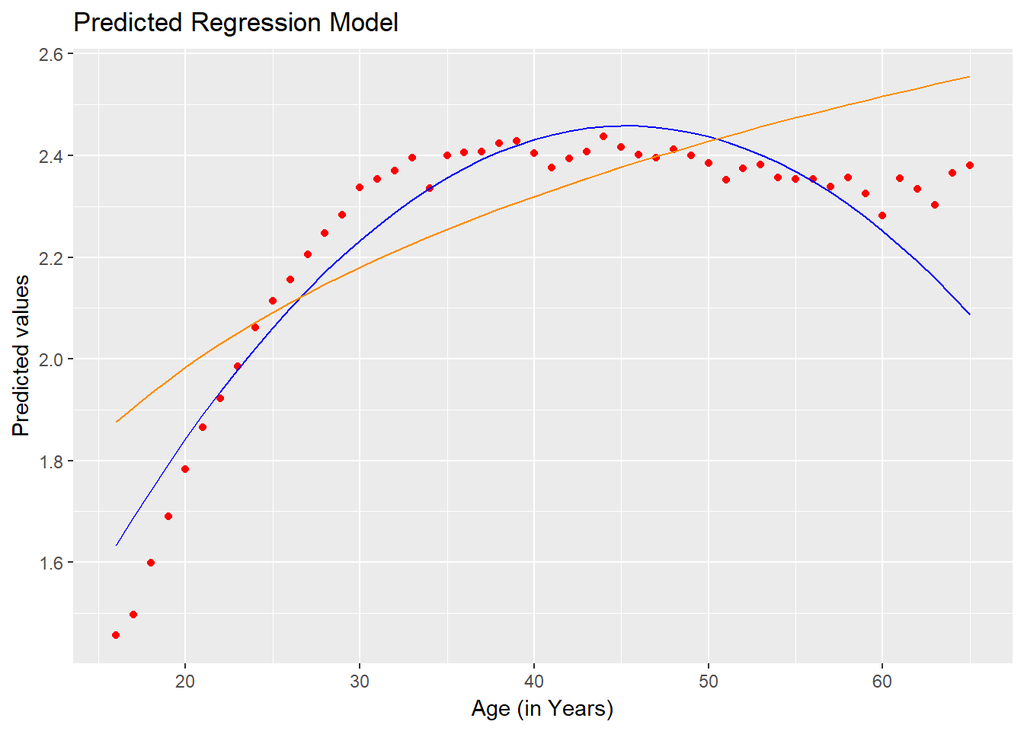

# Estimate regression models 2

Now we will estimate a quadratic model for `annualpay` (`annualpay ~ age + agesq`) on a subsets of data in order to compare these. When you know that you will be working with different subsets of data, the best way of doing that in R is to create a new factor variale (here `subset_ind`) which allows you to separate the data accordingly.

We will create two subgroups: 1) Males with a first degree and 2) Males with no degree. You may want to check the values of the `degree` variable in order to define these correctly.

`r data_USoc$subset_ind <- "none" # default group data_USoc$subset_ind[data_USoc$gender == "male" & data_USoc$degree == "first degree"] <- "Male with first degree" data_USoc$subset_ind[XXXX] <- "Male without first degree" # select all males with no degree data_USoc$subset_ind <- as.factor(data_USoc$subset_ind) data_USoc %>% count(subset_ind)`

`r data_USoc$subset_ind <- "none" # default group data_USoc$subset_ind[data_USoc$gender == "male" & data_USoc$degree == "first degree"] <- "Male with first degree" data_USoc$subset_ind[data_USoc$gender == "male" & data_USoc$degree == "no degree"] <- "Male without first degree" data_USoc$subset_ind <- as.factor(data_USoc$subset_ind) data_USoc %>% count(subset_ind)`

# A tibble: 3 x 2 subset_ind n 1 Male with first degree 4464 2 Male without first degree 17626 3 none 34688

We will want to save the model predictions and for this purpose we pre-define a variable in which we will save the predictions.

`r data_USoc$pred_mod5 <- 0 # set the prediction to 0 by default`

Now we estimate the model for the male with first degree subgroup. Note that the `lm` function accepts a `subset` argument which allows you to select a subset of observations, such as the group of all males with first degree.

`r mod5_md <- lm(XXXX ~ XXXX + XXXX, data = XXXX, subset = (subset_ind == XXXX)) stargazer_HC(XXXX) data_USoc$pred_mod5[data_USoc$subset_ind==XXXX] <- mod5_md$fitted.values`

`r mod5_md <- lm(annualpay ~ age + agesq, data = data_USoc, subset = (subset_ind == "Male with first degree")) stargazer_HC(mod5_md)`

========================================================= Dependent variable: ————————————- annualpay

age 3,924.330***  
(187.780)

agesq -4,251.222***  
(225.948)

Constant -53,414.740***  
(3,703.243)

[output not shown]

age 1,949.206***  
(45.437)

agesq -2,099.132***  
(56.181)

Constant -21,087.680***  
(858.212)

Observations 17,626  
R2 0.137  
Adjusted R2 0.137  
Residual Std. Error 12,592.500 (df = 17623)  
F Statistic 1,397.954*** (df = 2; 17623)  
========================================================= Note: *p<0.1; **p<0.05;*** p<0.01 Robust standard errors in parenthesis

```r
data_USoc$pred_mod5[data_USoc$subset_ind=="Male without first degree"] <- mod5_mnd$fitted.values
```

Now we plot the predicted values for the two specifications.

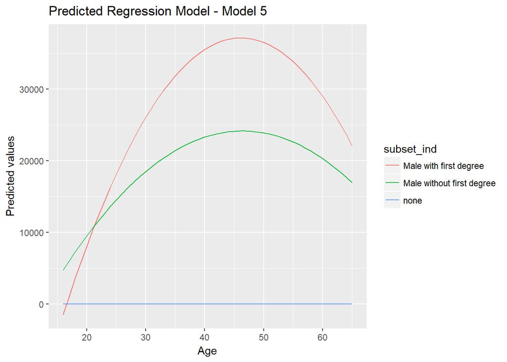

```r
ggplot(data_USoc, aes(x=age,y=pred_mod5,color = subset_ind)) +
  geom_line() +
  ggtitle("Predicted Regression Model - Model 5") +
  ylab("Predicted values") +
  xlab("Age")
```

You will see that we have the “none” category plotted as well (of course we didn’t estimate this). You could remove these data before plotting

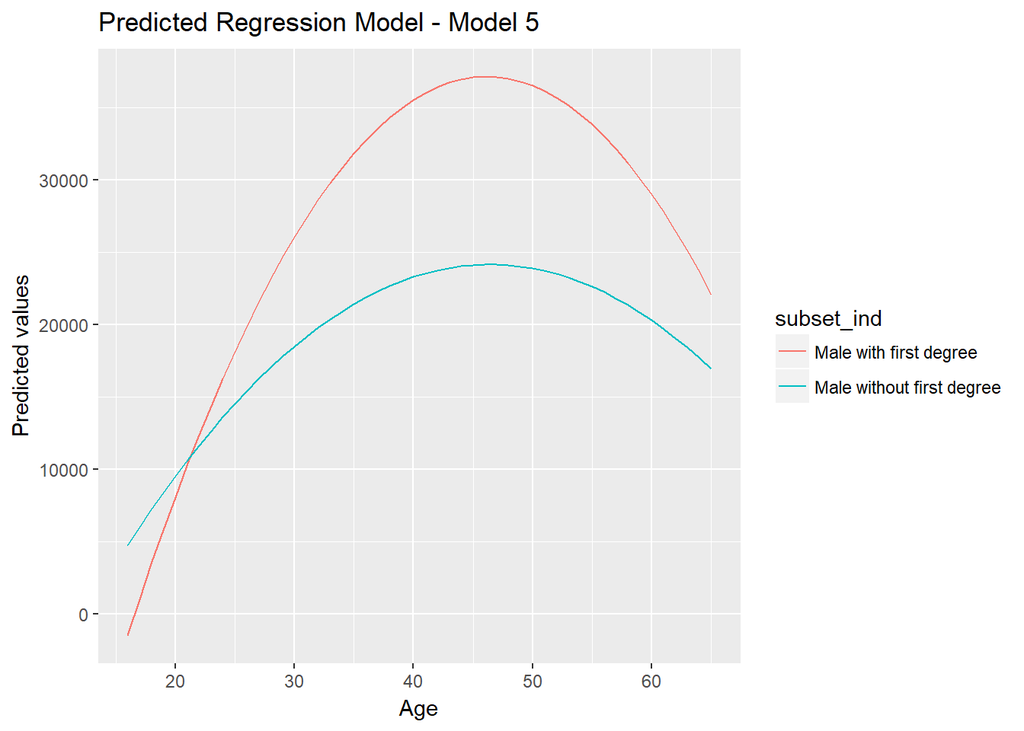

```r
data_temp <- data_USoc %>% filter(subset_ind != "none")  # remove observations with subset_ind == "none"
ggplot(data_temp, aes(x=age,y=pred_mod5,color = subset_ind)) +
  geom_line() +
  ggtitle("Predicted Regression Model - Model 5") +
  ylab("Predicted values") +
  xlab("Age")
```

END OF INSTRUCTIONS